# DaVinci Bi-modal integration: MISAR-seq (RNA + ATAC)

# Overview

This notebook runs a **bi-modal integration** workflow (RNA + ATAC) for MISAR-seq data using **DaVinci**. The overall workflow is:

1. **Horizontal integration** within each modality
2. **Vertical (cross-modality) integration** between RNA and ATAC, followed by clustering, optional spatial refinement, and visualization

## Setup

Load DaVinci and set the working directory.

```r
library(DaVinci)
library(ggpubr)

setwd("~/For_Tutorial/MISAR-seq/")
```

# Part I — Preprocess RNA across slices

We load each slice from `data.dir/<slice>/RNA.RDS`. Each RDS is expected to contain: - `mat`: feature-by-spot raw counts matrix - `coor`: spot-by-(x,y) coordinate matrix

For a quick demo, the script subsets to two slices (`dataset.opts[3:4]`). Remove or modify that line to run all sections.

```r
data.dir <- "~/For_Tutorial/MISAR-seq/data/"


dataset.opts <- list.files(data.dir)

# Work on 2 slices (E15 and E18) as a quick demo
dataset.opts <- dataset.opts[3:4]

Y.list <- list()
L.list <- list()
coor.list <- list()

for (ii in seq_along(dataset.opts)) {
  input <- readRDS(paste0(data.dir, dataset.opts[ii], "/RNA.RDS"))

  fin <- preprocess(
    input$mat,
    input$coor,
    type = "rna",
    graph.opt = "Tri.mesh",
    frac.thr = 0.95
  )

  Y.list[[ii]] <- fin$mat
  L.list[[ii]] <- fin$L
  coor.list[[ii]] <- fin$coor
}

names(coor.list) <- dataset.opts
```

## Run RNA horizontal integration

`Horizontal.Integration.Assemble()` searches over a candidate list of latent dimensions (`k.arg.list`) and integrates robust latent variables across sections.

```r
RNA.res <- Horizontal.Integration.Assemble(
              dataset.opts = dataset.opts,
              Y.list  = Y.list,
              L.list  = L.list,
              coor.list = coor.list,
              k.arg.list = c(4, 6, 8, 10, 11, 12, 13, 15, 16, 18, 20, 22, 24)
            )
```

# Part II — Preprocess ATAC across slices

We repeat the preprocessing for ATAC from `data.dir/<slice>/ATAC.RDS`. In the original script, `type` is commented out in `preprocess()` for ATAC. If `preprocess()` requires a type, set it explicitly (e.g., `type="rna"` to match other scripts, or `type="atac"` for ATAC-specific pipelines).

```r
Y.list <- list()
L.list <- list()
coor.list <- list()

for (ii in seq_along(dataset.opts)) {
  input <- readRDS(paste0(data.dir, dataset.opts[ii], "/ATAC.RDS"))

  fin <- preprocess(
            input$mat,
            input$coor,
            graph.opt = "Tri.mesh",
            frac.thr = 0.95
  )

  Y.list[[ii]] <- fin$mat
  L.list[[ii]] <- fin$L
  coor.list[[ii]] <- fin$coor
}

names(coor.list) <- dataset.opts
```

## ATAC horizontal integration

```r
ATAC.res <- Horizontal.Integration.Assemble(
              dataset.opts = dataset.opts,
              Y.list  = Y.list,
              L.list  = L.list,
              coor.list = coor.list,
              k.arg.list = c(4, 6, 8, 10, 11, 12, 13, 15, 16, 18, 20, 22, 24)
        )
```

# Part III — Cross-modality integration, clustering, refinement, visualization

## Align shared pixels between modalities

We intersect the row identifiers of RNA and ATAC integrated matrices so that both modalities contain the same set of pixels.

```r
mat.RNA <- RNA.res$mat
mat.ATAC <- ATAC.res$mat

# Intersect pixels present in both modalities
sids.intersect <- intersect(rownames(mat.RNA), rownames(mat.ATAC))
mat.RNA <- mat.RNA[sids.intersect, ]
mat.ATAC <- mat.ATAC[sids.intersect, ]

sids <- rownames(mat.RNA)
mat.slice.id <- unlist(lapply(strsplit(sids, "_"), function(x){x[1]}))
```

## Bi-modal integration and clustering

`BiModalIntegration()` constructs a shared neighbor graph across RNA and ATAC representations. We then cluster the integrated SNN graph using `leiden_adaptive()`.

```r
integration.res <- BiModalIntegration(
                      modal.1 = mat.RNA,
                      modal.2 = mat.ATAC,
                      n_neighbors = 50,
                      n_neighbors_large = 50,
                      L2norm = "column"
)
```

```
## [1] "No adjustment with reference UMI."
```

```r
partition <- leiden_adaptive(
                      integration.res$snn.mat,
                      num.of.cluster = 15,
                      resolution.start = 0.4,
                      adaptive.size = 2,
                      method = "louvain"
)
```

```
## 1.6 0.8 1.6
```

```
## 1.2 0.8 1.6
```

```
## 1.4 1.2 1.6
```

```
## 1.3 1.2 1.4
```

```
## 1.35 1.3 1.4
```

```
## 1.375 1.35 1.4
```

```r
partition <- as.character(partition)
names(partition) <- sids
```

## Spatial refinement (local smoothing)

We refine the cluster labels within each slice using KNN-based local smoothing via `DaVinci:::refinement()`.

```r
partition.smooth <- partition

for (ii in seq_along(dataset.opts)) {
  subpart.index <- which(mat.slice.id == dataset.opts[ii])

  p.part <- partition[subpart.index]
  p.part <- DaVinci:::refinement(
                  p.part,
                  as.matrix(coor.list[[ii]])[names(p.part), ],
                  neighbor.option = "KNN",
                  neighbor.arg = 8,
                  tasks = "discrete"
  )

  partition.smooth[subpart.index] <- p.part
}
```

## Visualize refined clusters

Finally, we plot clusters for each slice using `scatter.DiscretePlot.list()` and arrange them side-by-side.

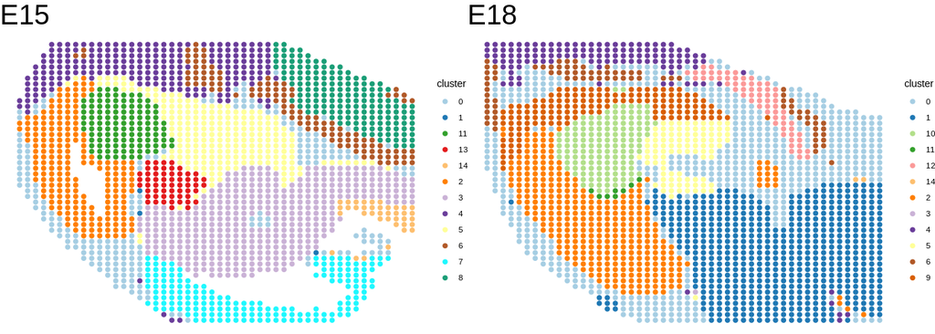

```r
par.to_plot <- partition.smooth

plot.list <- scatter.DiscretePlot.list(
  par.to_plot,
  coor.list,
  mat.slice.id,
  dataset.opts,
  pt.size = 2,
  title.size = 30,
  orientation = "x-y",
  ratio = NULL,
  return.obj = TRUE
)

ggarrange(plotlist = plot.list, nrow = 1)
```